# Risk Factor Analysis

## Outcome Variable

**Outcome Variable:** haz

## Predictor Variables

**Intervention Variable:** feducyrs

**Adjustment Set:**

- arm
- W_mage
- meducyrs
- hhwealth_quart
- W_mhtcm
- W_mwtkg
- W_mbmi
- W_gagebrth
- W_birthwt
- W_birthlen
- single
- impsan
- delta_W_mage
- delta_meducyrs
- delta_hhwealth_quart
- delta_W_mhtcm
- delta_W_mwtkg
- delta_W_mbmi
- delta_W_gagebrth
- delta_W_birthwt
- delta_W_birthlen
- delta_single
- delta_impsan

## Stratifying Variables

The analysis was stratified on these variable(s):

- agecat
- studyid
- country

## Data Summary

| agecat | studyid | country | feducyrs | n_cell | n | outcome_variable |
| --- | --- | --- | --- | --- | --- | --- |
| Birth | ki0047075b-MAL-ED | BANGLADESH | High | 47 | 129 | haz |
| Birth | ki0047075b-MAL-ED | BANGLADESH | Low | 36 | 129 | haz |
| Birth | ki0047075b-MAL-ED | BANGLADESH | Medium | 46 | 129 | haz |
| Birth | ki0047075b-MAL-ED | INDIA | High | 7 | 24 | haz |
| Birth | ki0047075b-MAL-ED | INDIA | Low | 14 | 24 | haz |
| Birth | ki0047075b-MAL-ED | INDIA | Medium | 3 | 24 | haz |
| Birth | ki0047075b-MAL-ED | NEPAL | High | 3 | 10 | haz |
| Birth | ki0047075b-MAL-ED | NEPAL | Low | 4 | 10 | haz |
| Birth | ki0047075b-MAL-ED | NEPAL | Medium | 3 | 10 | haz |
| Birth | ki0047075b-MAL-ED | PERU | High | 86 | 194 | haz |
| Birth | ki0047075b-MAL-ED | PERU | Low | 58 | 194 | haz |
| Birth | ki0047075b-MAL-ED | PERU | Medium | 50 | 194 | haz |
| Birth | ki0047075b-MAL-ED | SOUTH AFRICA | High | 10 | 33 | haz |
| Birth | ki0047075b-MAL-ED | SOUTH AFRICA | Low | 14 | 33 | haz |
| Birth | ki0047075b-MAL-ED | SOUTH AFRICA | Medium | 9 | 33 | haz |
| Birth | ki0047075b-MAL-ED | TANZANIA, UNITED REPUBLIC OF | High | 66 | 103 | haz |
| Birth | ki0047075b-MAL-ED | TANZANIA, UNITED REPUBLIC OF | Low | 27 | 103 | haz |
| Birth | ki0047075b-MAL-ED | TANZANIA, UNITED REPUBLIC OF | Medium | 10 | 103 | haz |
| Birth | ki1000304b-SAS-CompFeed | INDIA | High | 299 | 1249 | haz |
| Birth | ki1000304b-SAS-CompFeed | INDIA | Low | 543 | 1249 | haz |
| Birth | ki1000304b-SAS-CompFeed | INDIA | Medium | 407 | 1249 | haz |
| Birth | ki1017093b-PROVIDE | BANGLADESH | High | 163 | 539 | haz |
| Birth | ki1017093b-PROVIDE | BANGLADESH | Low | 187 | 539 | haz |
| Birth | ki1017093b-PROVIDE | BANGLADESH | Medium | 189 | 539 | haz |
| Birth | ki1017093c-NIH-Crypto | BANGLADESH | High | 284 | 732 | haz |
| Birth | ki1017093c-NIH-Crypto | BANGLADESH | Low | 235 | 732 | haz |
| Birth | ki1017093c-NIH-Crypto | BANGLADESH | Medium | 213 | 732 | haz |
| Birth | ki1113344-GMS-Nepal | NEPAL | High | 172 | 694 | haz |
| Birth | ki1113344-GMS-Nepal | NEPAL | Low | 296 | 694 | haz |
| Birth | ki1113344-GMS-Nepal | NEPAL | Medium | 226 | 694 | haz |

[output cut: 135 more lines]

The following strata were considered:

- agecat: 24 months, studyid: ki0047075b-MAL-ED, country: BANGLADESH
- agecat: 24 months, studyid: ki0047075b-MAL-ED, country: INDIA
- agecat: 24 months, studyid: ki0047075b-MAL-ED, country: NEPAL
- agecat: 24 months, studyid: ki0047075b-MAL-ED, country: PERU
- agecat: 24 months, studyid: ki0047075b-MAL-ED, country: SOUTH AFRICA
- agecat: 24 months, studyid: ki0047075b-MAL-ED, country: TANZANIA, UNITED REPUBLIC OF
- agecat: 24 months, studyid: ki1017093b-PROVIDE, country: BANGLADESH
- agecat: 24 months, studyid: ki1017093c-NIH-Crypto, country: BANGLADESH
- agecat: 24 months, studyid: ki1066203-TanzaniaChild2, country: TANZANIA, UNITED REPUBLIC OF
- agecat: 24 months, studyid: ki1113344-GMS-Nepal, country: NEPAL
- agecat: 24 months, studyid: ki1119695-PROBIT, country: BELARUS
- agecat: 24 months, studyid: ki1126311-ZVITAMBO, country: ZIMBABWE
- agecat: 24 months, studyid: ki1135781-COHORTS, country: GUATEMALA
- agecat: 24 months, studyid: ki1135781-COHORTS, country: INDIA
- agecat: 24 months, studyid: ki1135781-COHORTS, country: PHILIPPINES
- agecat: 24 months, studyid: ki1148112-LCNI-5, country: MALAWI
- agecat: 24 months, studyid: kiGH5241-JiVitA-3, country: BANGLADESH
- agecat: 24 months, studyid: kiGH5241-JiVitA-4, country: BANGLADESH
- agecat: 6 months, studyid: ki0047075b-MAL-ED, country: BANGLADESH
- agecat: 6 months, studyid: ki0047075b-MAL-ED, country: INDIA
- agecat: 6 months, studyid: ki0047075b-MAL-ED, country: NEPAL
- agecat: 6 months, studyid: ki0047075b-MAL-ED, country: PERU
- agecat: 6 months, studyid: ki0047075b-MAL-ED, country: SOUTH AFRICA
- agecat: 6 months, studyid: ki0047075b-MAL-ED, country: TANZANIA, UNITED REPUBLIC OF
- agecat: 6 months, studyid: ki1000304b-SAS-CompFeed, country: INDIA
- agecat: 6 months, studyid: ki1000304b-SAS-FoodSuppl, country: INDIA
- agecat: 6 months, studyid: ki1017093b-PROVIDE, country: BANGLADESH
- agecat: 6 months, studyid: ki1017093c-NIH-Crypto, country: BANGLADESH
- agecat: 6 months, studyid: ki1066203-TanzaniaChild2, country: TANZANIA, UNITED REPUBLIC OF
- agecat: 6 months, studyid: ki1113344-GMS-Nepal, country: NEPAL
- agecat: 6 months, studyid: ki1119695-PROBIT, country: BELARUS
- agecat: 6 months, studyid: ki1126311-ZVITAMBO, country: ZIMBABWE
- agecat: 6 months, studyid: ki1135781-COHORTS, country: GUATEMALA
- agecat: 6 months, studyid: ki1135781-COHORTS, country: INDIA
- agecat: 6 months, studyid: ki1135781-COHORTS, country: PHILIPPINES
- agecat: 6 months, studyid: ki1148112-LCNI-5, country: MALAWI
- agecat: 6 months, studyid: kiGH5241-JiVitA-3, country: BANGLADESH
- agecat: 6 months, studyid: kiGH5241-JiVitA-4, country: BANGLADESH
- agecat: Birth, studyid: ki0047075b-MAL-ED, country: BANGLADESH
- agecat: Birth, studyid: ki0047075b-MAL-ED, country: INDIA
- agecat: Birth, studyid: ki0047075b-MAL-ED, country: NEPAL
- agecat: Birth, studyid: ki0047075b-MAL-ED, country: PERU
- agecat: Birth, studyid: ki0047075b-MAL-ED, country: SOUTH AFRICA
- agecat: Birth, studyid: ki0047075b-MAL-ED, country: TANZANIA, UNITED REPUBLIC OF
- agecat: Birth, studyid: ki1000304b-SAS-CompFeed, country: INDIA
- agecat: Birth, studyid: ki1017093b-PROVIDE, country: BANGLADESH
- agecat: Birth, studyid: ki1017093c-NIH-Crypto, country: BANGLADESH
- agecat: Birth, studyid: ki1113344-GMS-Nepal, country: NEPAL
- agecat: Birth, studyid: ki1119695-PROBIT, country: BELARUS
- agecat: Birth, studyid: ki1126311-ZVITAMBO, country: ZIMBABWE
- agecat: Birth, studyid: ki1135781-COHORTS, country: GUATEMALA
- agecat: Birth, studyid: ki1135781-COHORTS, country: INDIA
- agecat: Birth, studyid: ki1135781-COHORTS, country: PHILIPPINES
- agecat: Birth, studyid: kiGH5241-JiVitA-3, country: BANGLADESH
- agecat: Birth, studyid: kiGH5241-JiVitA-4, country: BANGLADESH

### Dropped Strata

Some strata were dropped due to rare outcomes:

- agecat: Birth, studyid: ki0047075b-MAL-ED, country: INDIA
- agecat: Birth, studyid: ki0047075b-MAL-ED, country: NEPAL
- agecat: 24 months, studyid: ki1066203-TanzaniaChild2, country: TANZANIA, UNITED REPUBLIC OF

## Methods Detail

We’re interested in the causal parameters $E[Y_a]$ for all values of $a \in \mathcal{A}$. These parameters represent the mean outcome if, possibly contrary to fact, we intervened to set all units to have $A=a$. Under the randomization and positivity assumptions, these are identified by the statistical parameters $\psi_a=E_W[E_{Y|A,W}(Y|A=a,W)]$. In addition, we’re interested in the mean of $Y$, $E[Y]$ under no intervention (the observed mean). We will estimate these parameters by using SuperLearner to fit the relevant likelihood factors – $E_{Y|A,W}(Y|A=a,W)$ and $p(A=a|W)$, and then updating our likelihood fit using a joint TMLE.

For unadjusted analyses ($W=\{\}$), initial likelihoods were estimated using Lrnr_glm to estimate the simple $E(Y|A)$ and Lrnr_mean to estimate $p(A)$. For adjusted analyses, a small library containing Lrnr_glmnet, Lrnr_xgboost, and Lrnr_mean was used.

Having estimated these parameters, we will then use the delta method to estimate relative risks and attributable risks relative to a prespecified baseline level of $A$.

# Results Detail

## Results Plots

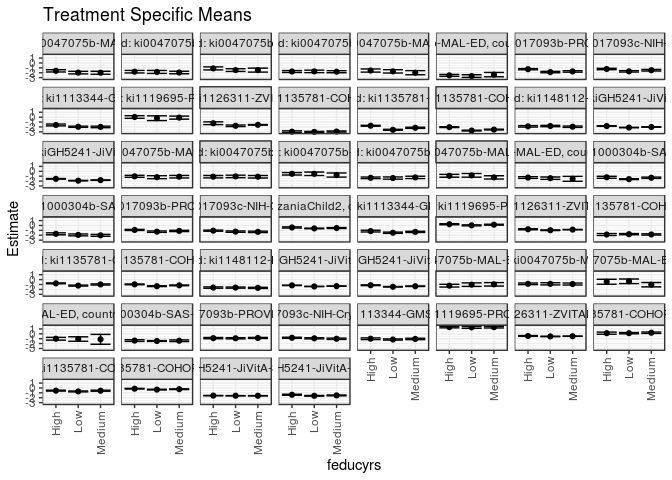

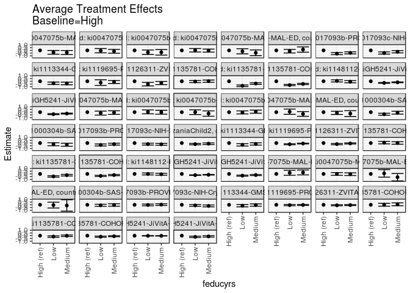

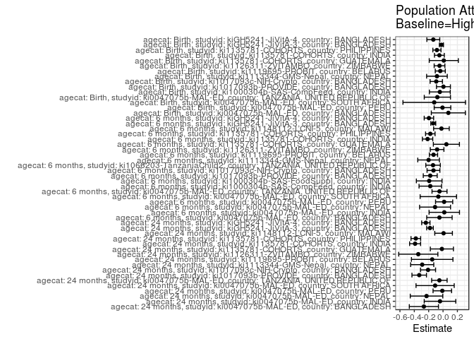

## Results Table

### Parameter: TSM

| agecat | studyid | country | intervention_level | baseline_level | estimate | ci_lower | ci_upper |
| --- | --- | --- | --- | --- | --- | --- | --- |
| Birth | ki0047075b-MAL-ED | BANGLADESH | High | NA | -1.2352144 | -1.5140701 | -0.9563587 |
| Birth | ki0047075b-MAL-ED | BANGLADESH | Low | NA | -1.0249252 | -1.3847906 | -0.6650597 |
| Birth | ki0047075b-MAL-ED | BANGLADESH | Medium | NA | -0.9625477 | -1.3151024 | -0.6099930 |
| Birth | ki0047075b-MAL-ED | PERU | High | NA | -0.8569644 | -1.0253032 | -0.6886257 |
| Birth | ki0047075b-MAL-ED | PERU | Low | NA | -0.8605806 | -1.0800896 | -0.6410715 |
| Birth | ki0047075b-MAL-ED | PERU | Medium | NA | -0.8993939 | -1.1065942 | -0.6921936 |
| Birth | ki0047075b-MAL-ED | SOUTH AFRICA | High | NA | -0.4350000 | -0.9433959 | 0.0733959 |
| Birth | ki0047075b-MAL-ED | SOUTH AFRICA | Low | NA | -0.3378571 | -0.8038006 | 0.1280863 |
| Birth | ki0047075b-MAL-ED | SOUTH AFRICA | Medium | NA | -1.0355556 | -1.4792485 | -0.5918626 |
| Birth | ki0047075b-MAL-ED | TANZANIA, UNITED REPUBLIC OF | High | NA | -1.0117429 | -1.2963208 | -0.7271651 |
| Birth | ki0047075b-MAL-ED | TANZANIA, UNITED REPUBLIC OF | Low | NA | -1.0647888 | -1.5152826 | -0.6142949 |
| Birth | ki0047075b-MAL-ED | TANZANIA, UNITED REPUBLIC OF | Medium | NA | -1.1321436 | -2.1379864 | -0.1263009 |
| Birth | ki1000304b-SAS-CompFeed | INDIA | High | NA | -1.3854509 | -1.5537179 | -1.2171839 |
| Birth | ki1000304b-SAS-CompFeed | INDIA | Low | NA | -1.4726596 | -1.5602580 | -1.3850613 |
| Birth | ki1000304b-SAS-CompFeed | INDIA | Medium | NA | -1.4174059 | -1.5795890 | -1.2552228 |
| Birth | ki1017093b-PROVIDE | BANGLADESH | High | NA | -0.8910323 | -1.0182266 | -0.7638380 |
| Birth | ki1017093b-PROVIDE | BANGLADESH | Low | NA | -0.9188807 | -1.0352433 | -0.8025182 |
| Birth | ki1017093b-PROVIDE | BANGLADESH | Medium | NA | -0.8546984 | -0.9642700 | -0.7451268 |
| Birth | ki1017093c-NIH-Crypto | BANGLADESH | High | NA | -0.8151681 | -0.9278174 | -0.7025189 |
| Birth | ki1017093c-NIH-Crypto | BANGLADESH | Low | NA | -0.9247402 | -1.0393817 | -0.8100987 |
| Birth | ki1017093c-NIH-Crypto | BANGLADESH | Medium | NA | -1.0145661 | -1.1497627 | -0.8793694 |
| Birth | ki1113344-GMS-Nepal | NEPAL | High | NA | -1.0038835 | -1.1709743 | -0.8367926 |
| Birth | ki1113344-GMS-Nepal | NEPAL | Low | NA | -1.1716484 | -1.2924141 | -1.0508828 |
| Birth | ki1113344-GMS-Nepal | NEPAL | Medium | NA | -1.0484306 | -1.1863652 | -0.9104960 |
| Birth | ki1119695-PROBIT | BELARUS | High | NA | 1.3740499 | 1.2132195 | 1.5348803 |
| Birth | ki1119695-PROBIT | BELARUS | Low | NA | 1.3176904 | 1.1255135 | 1.5098674 |
| Birth | ki1119695-PROBIT | BELARUS | Medium | NA | 1.3463862 | 1.1856793 | 1.5070931 |
| Birth | ki1126311-ZVITAMBO | ZIMBABWE | High | NA | -0.4488223 | -0.5263138 | -0.3713307 |
| Birth | ki1126311-ZVITAMBO | ZIMBABWE | Low | NA | -0.5370493 | -0.5918684 | -0.4822301 |
| Birth | ki1126311-ZVITAMBO | ZIMBABWE | Medium | NA | -0.4969738 | -0.5212225 | -0.4727251 |

[output cut: 126 more lines]

### Parameter: E(Y)

| agecat | studyid | country | intervention_level | baseline_level | estimate | ci_lower | ci_upper |
| --- | --- | --- | --- | --- | --- | --- | --- |
| Birth | ki0047075b-MAL-ED | BANGLADESH | NA | NA | -1.1609302 | -1.3461119 | -0.9757486 |
| Birth | ki0047075b-MAL-ED | PERU | NA | NA | -0.8645361 | -0.9887014 | -0.7403707 |
| Birth | ki0047075b-MAL-ED | SOUTH AFRICA | NA | NA | -0.5575758 | -0.8541170 | -0.2610345 |
| Birth | ki0047075b-MAL-ED | TANZANIA, UNITED REPUBLIC OF | NA | NA | -1.0906796 | -1.3207118 | -0.8606474 |
| Birth | ki1000304b-SAS-CompFeed | INDIA | NA | NA | -1.4300160 | -1.5090211 | -1.3510109 |
| Birth | ki1017093b-PROVIDE | BANGLADESH | NA | NA | -0.8851020 | -0.9601332 | -0.8100709 |
| Birth | ki1017093c-NIH-Crypto | BANGLADESH | NA | NA | -0.9094945 | -0.9809370 | -0.8380521 |
| Birth | ki1113344-GMS-Nepal | NEPAL | NA | NA | -1.0885159 | -1.1686181 | -1.0084136 |
| Birth | ki1119695-PROBIT | BELARUS | NA | NA | 1.3357134 | 1.1759964 | 1.4954304 |
| Birth | ki1126311-ZVITAMBO | ZIMBABWE | NA | NA | -0.4977261 | -0.5185420 | -0.4769102 |
| Birth | ki1135781-COHORTS | GUATEMALA | NA | NA | 0.1369030 | 0.0500914 | 0.2237146 |
| Birth | ki1135781-COHORTS | INDIA | NA | NA | -0.6011965 | -0.6594222 | -0.5429708 |
| Birth | ki1135781-COHORTS | PHILIPPINES | NA | NA | -0.2407379 | -0.2807613 | -0.2007145 |
| Birth | kiGH5241-JiVitA-3 | BANGLADESH | NA | NA | -1.5843618 | -1.6039583 | -1.5647653 |
| Birth | kiGH5241-JiVitA-4 | BANGLADESH | NA | NA | -1.5242226 | -1.5742923 | -1.4741529 |
| 6 months | ki0047075b-MAL-ED | BANGLADESH | NA | NA | -1.0786869 | -1.2229595 | -0.9344142 |
| 6 months | ki0047075b-MAL-ED | INDIA | NA | NA | -1.0820652 | -1.2263805 | -0.9377499 |
| 6 months | ki0047075b-MAL-ED | NEPAL | NA | NA | -0.6179474 | -0.8011766 | -0.4347182 |
| 6 months | ki0047075b-MAL-ED | PERU | NA | NA | -1.3208519 | -1.4383850 | -1.2033189 |
| 6 months | ki0047075b-MAL-ED | SOUTH AFRICA | NA | NA | -0.9829167 | -1.1753367 | -0.7904967 |
| 6 months | ki0047075b-MAL-ED | TANZANIA, UNITED REPUBLIC OF | NA | NA | -1.3283002 | -1.4654809 | -1.1911194 |
| 6 months | ki1000304b-SAS-CompFeed | INDIA | NA | NA | -1.4006377 | -1.4802862 | -1.3209891 |
| 6 months | ki1000304b-SAS-FoodSuppl | INDIA | NA | NA | -1.8986842 | -2.0118892 | -1.7854792 |
| 6 months | ki1017093b-PROVIDE | BANGLADESH | NA | NA | -1.0916915 | -1.1661176 | -1.0172654 |
| 6 months | ki1017093c-NIH-Crypto | BANGLADESH | NA | NA | -1.1986783 | -1.2700937 | -1.1272630 |
| 6 months | ki1066203-TanzaniaChild2 | TANZANIA, UNITED REPUBLIC OF | NA | NA | -0.5442042 | -0.5932639 | -0.4951446 |
| 6 months | ki1113344-GMS-Nepal | NEPAL | NA | NA | -1.3525459 | -1.4308373 | -1.2742545 |
| 6 months | ki1119695-PROBIT | BELARUS | NA | NA | 0.1181349 | 0.0244298 | 0.2118400 |
| 6 months | ki1126311-ZVITAMBO | ZIMBABWE | NA | NA | -0.8606958 | -0.8865994 | -0.8347923 |
| 6 months | ki1135781-COHORTS | GUATEMALA | NA | NA | -1.8074115 | -1.8776669 | -1.7371562 |
| 6 months | ki1135781-COHORTS | INDIA | NA | NA | -0.9755018 | -1.0332483 | -0.9177553 |
| 6 months | ki1135781-COHORTS | PHILIPPINES | NA | NA | -1.1419345 | -1.1847445 | -1.0991244 |
| 6 months | ki1148112-LCNI-5 | MALAWI | NA | NA | -1.6442734 | -1.7137349 | -1.5748119 |
| 6 months | kiGH5241-JiVitA-3 | BANGLADESH | NA | NA | -1.3073109 | -1.3309979 | -1.2836240 |
| 6 months | kiGH5241-JiVitA-4 | BANGLADESH | NA | NA | -1.3420154 | -1.3798750 | -1.3041557 |
| 24 months | ki0047075b-MAL-ED | BANGLADESH | NA | NA | -1.8767521 | -2.0339896 | -1.7195147 |
| 24 months | ki0047075b-MAL-ED | INDIA | NA | NA | -1.8269318 | -1.9896129 | -1.6642507 |
| 24 months | ki0047075b-MAL-ED | NEPAL | NA | NA | -1.3417582 | -1.5289233 | -1.1545932 |
| 24 months | ki0047075b-MAL-ED | PERU | NA | NA | -1.7589939 | -1.8878675 | -1.6301203 |
| 24 months | ki0047075b-MAL-ED | SOUTH AFRICA | NA | NA | -1.6565385 | -1.8628022 | -1.4502747 |
| 24 months | ki0047075b-MAL-ED | TANZANIA, UNITED REPUBLIC OF | NA | NA | -2.5846893 | -2.7309103 | -2.4384682 |
| 24 months | ki1017093b-PROVIDE | BANGLADESH | NA | NA | -1.6024221 | -1.6857420 | -1.5191023 |
| 24 months | ki1017093c-NIH-Crypto | BANGLADESH | NA | NA | -1.4412646 | -1.5249156 | -1.3576135 |
| 24 months | ki1113344-GMS-Nepal | NEPAL | NA | NA | -1.8889117 | -1.9744778 | -1.8033456 |
| 24 months | ki1119695-PROBIT | BELARUS | NA | NA | -0.1248692 | -0.4220079 | 0.1722694 |
| 24 months | ki1126311-ZVITAMBO | ZIMBABWE | NA | NA | -1.5903795 | -1.6477380 | -1.5330211 |
| 24 months | ki1135781-COHORTS | GUATEMALA | NA | NA | -2.9834879 | -3.0503374 | -2.9166384 |
| 24 months | ki1135781-COHORTS | INDIA | NA | NA | -2.1479058 | -2.2089283 | -2.0868833 |
| 24 months | ki1135781-COHORTS | PHILIPPINES | NA | NA | -2.4268626 | -2.4728444 | -2.3808807 |
| 24 months | ki1148112-LCNI-5 | MALAWI | NA | NA | -1.8787566 | -1.9605168 | -1.7969964 |
| 24 months | kiGH5241-JiVitA-3 | BANGLADESH | NA | NA | -2.0070517 | -2.0348225 | -1.9792810 |
| 24 months | kiGH5241-JiVitA-4 | BANGLADESH | NA | NA | -1.7817125 | -1.8182569 | -1.7451681 |

### Parameter: ATE

| agecat | studyid | country | intervention_level | baseline_level | estimate | ci_lower | ci_upper |
| --- | --- | --- | --- | --- | --- | --- | --- |
| Birth | ki0047075b-MAL-ED | BANGLADESH | High | High | 0.0000000 | 0.0000000 | 0.0000000 |
| Birth | ki0047075b-MAL-ED | BANGLADESH | Low | High | 0.2102892 | -0.2491907 | 0.6697691 |
| Birth | ki0047075b-MAL-ED | BANGLADESH | Medium | High | 0.2726667 | -0.1768714 | 0.7222048 |
| Birth | ki0047075b-MAL-ED | PERU | High | High | 0.0000000 | 0.0000000 | 0.0000000 |
| Birth | ki0047075b-MAL-ED | PERU | Low | High | -0.0036162 | -0.2573035 | 0.2500712 |
| Birth | ki0047075b-MAL-ED | PERU | Medium | High | -0.0424295 | -0.2907394 | 0.2058804 |
| Birth | ki0047075b-MAL-ED | SOUTH AFRICA | High | High | 0.0000000 | 0.0000000 | 0.0000000 |
| Birth | ki0047075b-MAL-ED | SOUTH AFRICA | Low | High | 0.0971429 | -0.5924727 | 0.7867584 |
| Birth | ki0047075b-MAL-ED | SOUTH AFRICA | Medium | High | -0.6005556 | -1.2753368 | 0.0742257 |
| Birth | ki0047075b-MAL-ED | TANZANIA, UNITED REPUBLIC OF | High | High | 0.0000000 | 0.0000000 | 0.0000000 |
| Birth | ki0047075b-MAL-ED | TANZANIA, UNITED REPUBLIC OF | Low | High | -0.0530458 | -0.5880199 | 0.4819283 |
| Birth | ki0047075b-MAL-ED | TANZANIA, UNITED REPUBLIC OF | Medium | High | -0.1204007 | -1.1676723 | 0.9268709 |
| Birth | ki1000304b-SAS-CompFeed | INDIA | High | High | 0.0000000 | 0.0000000 | 0.0000000 |
| Birth | ki1000304b-SAS-CompFeed | INDIA | Low | High | -0.0872088 | -0.2836848 | 0.1092673 |
| Birth | ki1000304b-SAS-CompFeed | INDIA | Medium | High | -0.0319550 | -0.2599794 | 0.1960694 |
| Birth | ki1017093b-PROVIDE | BANGLADESH | High | High | 0.0000000 | 0.0000000 | 0.0000000 |
| Birth | ki1017093b-PROVIDE | BANGLADESH | Low | High | -0.0278485 | -0.1880582 | 0.1323612 |
| Birth | ki1017093b-PROVIDE | BANGLADESH | Medium | High | 0.0363338 | -0.1193439 | 0.1920116 |
| Birth | ki1017093c-NIH-Crypto | BANGLADESH | High | High | 0.0000000 | 0.0000000 | 0.0000000 |
| Birth | ki1017093c-NIH-Crypto | BANGLADESH | Low | High | -0.1095721 | -0.2669168 | 0.0477726 |
| Birth | ki1017093c-NIH-Crypto | BANGLADESH | Medium | High | -0.1993979 | -0.3719923 | -0.0268036 |
| Birth | ki1113344-GMS-Nepal | NEPAL | High | High | 0.0000000 | 0.0000000 | 0.0000000 |
| Birth | ki1113344-GMS-Nepal | NEPAL | Low | High | -0.1677650 | -0.3717529 | 0.0362230 |
| Birth | ki1113344-GMS-Nepal | NEPAL | Medium | High | -0.0445471 | -0.2590769 | 0.1699827 |
| Birth | ki1119695-PROBIT | BELARUS | High | High | 0.0000000 | 0.0000000 | 0.0000000 |
| Birth | ki1119695-PROBIT | BELARUS | Low | High | -0.0563595 | -0.1722057 | 0.0594867 |
| Birth | ki1119695-PROBIT | BELARUS | Medium | High | -0.0276637 | -0.1131200 | 0.0577926 |
| Birth | ki1126311-ZVITAMBO | ZIMBABWE | High | High | 0.0000000 | 0.0000000 | 0.0000000 |
| Birth | ki1126311-ZVITAMBO | ZIMBABWE | Low | High | -0.0882270 | -0.1825863 | 0.0061323 |
| Birth | ki1126311-ZVITAMBO | ZIMBABWE | Medium | High | -0.0481516 | -0.1286668 | 0.0323637 |

[output cut: 126 more lines]

### Parameter: PAR

| agecat | studyid | country | intervention_level | baseline_level | estimate | ci_lower | ci_upper |
| --- | --- | --- | --- | --- | --- | --- | --- |
| Birth | ki0047075b-MAL-ED | BANGLADESH | High | NA | 0.0742842 | -0.1630859 | 0.3116542 |
| Birth | ki0047075b-MAL-ED | PERU | High | NA | -0.0075717 | -0.1229545 | 0.1078112 |
| Birth | ki0047075b-MAL-ED | SOUTH AFRICA | High | NA | -0.1225758 | -0.5581866 | 0.3130351 |
| Birth | ki0047075b-MAL-ED | TANZANIA, UNITED REPUBLIC OF | High | NA | -0.0789367 | -0.2613719 | 0.1034986 |
| Birth | ki1000304b-SAS-CompFeed | INDIA | High | NA | -0.0445651 | -0.1896346 | 0.1005044 |
| Birth | ki1017093b-PROVIDE | BANGLADESH | High | NA | 0.0059302 | -0.0908668 | 0.1027273 |
| Birth | ki1017093c-NIH-Crypto | BANGLADESH | High | NA | -0.0943264 | -0.1800022 | -0.0086506 |
| Birth | ki1113344-GMS-Nepal | NEPAL | High | NA | -0.0846324 | -0.2282343 | 0.0589696 |
| Birth | ki1119695-PROBIT | BELARUS | High | NA | -0.0383365 | -0.1080751 | 0.0314021 |
| Birth | ki1126311-ZVITAMBO | ZIMBABWE | High | NA | -0.0489038 | -0.1234284 | 0.0256207 |
| Birth | ki1135781-COHORTS | GUATEMALA | High | NA | 0.0106651 | -0.1917252 | 0.2130554 |
| Birth | ki1135781-COHORTS | INDIA | High | NA | -0.0507436 | -0.1194925 | 0.0180052 |
| Birth | ki1135781-COHORTS | PHILIPPINES | High | NA | -0.0850900 | -0.1417822 | -0.0283978 |
| Birth | kiGH5241-JiVitA-3 | BANGLADESH | High | NA | -0.0223501 | -0.0507241 | 0.0060239 |
| Birth | kiGH5241-JiVitA-4 | BANGLADESH | High | NA | -0.1353641 | -0.2250714 | -0.0456568 |
| 6 months | ki0047075b-MAL-ED | BANGLADESH | High | NA | -0.0501654 | -0.2270945 | 0.1267638 |
| 6 months | ki0047075b-MAL-ED | INDIA | High | NA | 0.0176618 | -0.1939358 | 0.2292594 |
| 6 months | ki0047075b-MAL-ED | NEPAL | High | NA | -0.1108159 | -0.3260938 | 0.1044620 |
| 6 months | ki0047075b-MAL-ED | PERU | High | NA | 0.0154343 | -0.1040632 | 0.1349318 |
| 6 months | ki0047075b-MAL-ED | SOUTH AFRICA | High | NA | -0.0653020 | -0.3186870 | 0.1880830 |
| 6 months | ki0047075b-MAL-ED | TANZANIA, UNITED REPUBLIC OF | High | NA | -0.0490158 | -0.1534876 | 0.0554559 |
| 6 months | ki1000304b-SAS-CompFeed | INDIA | High | NA | -0.1773917 | -0.3339571 | -0.0208262 |
| 6 months | ki1000304b-SAS-FoodSuppl | INDIA | High | NA | -0.1927287 | -0.3713445 | -0.0141130 |
| 6 months | ki1017093b-PROVIDE | BANGLADESH | High | NA | -0.1782485 | -0.2752656 | -0.0812313 |
| 6 months | ki1017093c-NIH-Crypto | BANGLADESH | High | NA | -0.1331995 | -0.2223792 | -0.0440198 |
| 6 months | ki1066203-TanzaniaChild2 | TANZANIA, UNITED REPUBLIC OF | High | NA | -0.1389063 | -0.2398751 | -0.0379374 |
| 6 months | ki1113344-GMS-Nepal | NEPAL | High | NA | -0.2011801 | -0.3517051 | -0.0506552 |
| 6 months | ki1119695-PROBIT | BELARUS | High | NA | -0.1324485 | -0.1893487 | -0.0755482 |
| 6 months | ki1126311-ZVITAMBO | ZIMBABWE | High | NA | -0.0825735 | -0.1776479 | 0.0125009 |
| 6 months | ki1135781-COHORTS | GUATEMALA | High | NA | 0.0467956 | -0.1347512 | 0.2283425 |
| 6 months | ki1135781-COHORTS | INDIA | High | NA | -0.2151428 | -0.2870515 | -0.1432340 |
| 6 months | ki1135781-COHORTS | PHILIPPINES | High | NA | -0.1772227 | -0.2432043 | -0.1112412 |
| 6 months | ki1148112-LCNI-5 | MALAWI | High | NA | -0.0222128 | -0.1309067 | 0.0864810 |
| 6 months | kiGH5241-JiVitA-3 | BANGLADESH | High | NA | -0.1359840 | -0.1701505 | -0.1018175 |
| 6 months | kiGH5241-JiVitA-4 | BANGLADESH | High | NA | -0.1964632 | -0.2620943 | -0.1308321 |
| 24 months | ki0047075b-MAL-ED | BANGLADESH | High | NA | -0.2665475 | -0.4694853 | -0.0636097 |
| 24 months | ki0047075b-MAL-ED | INDIA | High | NA | -0.0421246 | -0.2618351 | 0.1775860 |
| 24 months | ki0047075b-MAL-ED | NEPAL | High | NA | -0.2297568 | -0.4561934 | -0.0033203 |
| 24 months | ki0047075b-MAL-ED | PERU | High | NA | -0.0099674 | -0.1389550 | 0.1190201 |
| 24 months | ki0047075b-MAL-ED | SOUTH AFRICA | High | NA | -0.1102426 | -0.3761601 | 0.1556748 |
| 24 months | ki0047075b-MAL-ED | TANZANIA, UNITED REPUBLIC OF | High | NA | -0.0508476 | -0.1585249 | 0.0568298 |
| 24 months | ki1017093b-PROVIDE | BANGLADESH | High | NA | -0.3316777 | -0.4328446 | -0.2305108 |
| 24 months | ki1017093c-NIH-Crypto | BANGLADESH | High | NA | -0.2088954 | -0.3138861 | -0.1039048 |
| 24 months | ki1113344-GMS-Nepal | NEPAL | High | NA | -0.2900658 | -0.4511319 | -0.1289997 |
| 24 months | ki1119695-PROBIT | BELARUS | High | NA | -0.1509417 | -0.4399161 | 0.1380328 |
| 24 months | ki1126311-ZVITAMBO | ZIMBABWE | High | NA | -0.3445275 | -0.6171634 | -0.0718915 |
| 24 months | ki1135781-COHORTS | GUATEMALA | High | NA | -0.0159850 | -0.1767666 | 0.1447966 |
| 24 months | ki1135781-COHORTS | INDIA | High | NA | -0.3890404 | -0.4653134 | -0.3127673 |
| 24 months | ki1135781-COHORTS | PHILIPPINES | High | NA | -0.3790718 | -0.4462931 | -0.3118506 |
| 24 months | ki1148112-LCNI-5 | MALAWI | High | NA | 0.0076909 | -0.1151226 | 0.1305045 |
| 24 months | kiGH5241-JiVitA-3 | BANGLADESH | High | NA | -0.1816082 | -0.2275289 | -0.1356875 |
| 24 months | kiGH5241-JiVitA-4 | BANGLADESH | High | NA | -0.2393427 | -0.2972328 | -0.1814526 |